# Responses to Assignment 2

# 1 About File

1. You are supposed to submit R Notebook File with a file name a2_YourID.nb.html.
- Some submitted a HTML file, such as a2_YourID.html. You need to create R Notebook. Use the template in Moodle. It creates a file with *.nb.html at the end.
- Some did not run each code chunk. You should run each code or select Run all under Run button. If some code chunk has a problem or an error, run each code chunk or use Run all chunk above or Run all chunk below, so the result appear in your R Notebook file.
2. You are supposed to write observations.
- Writing codes seem to be challenging, however, we are learning ‘data analysis’ not ‘prgraming’. Do not forget to write explanation of the data, questions and observations.
3. Cheat Sheets, Posit Primers, and the textbook ‘R for Data Science’ are the first set of references you should look at together wih my lecture materials.

# 2 Set up

```r
library(tidyverse)
library(gapminder)
```

The following is a short-hand of

```
df <- gapminder
df
```

```r
(df <- gapminder)
```

| country | continent | year | lifeExp | pop | gdpPercap |
| --- | --- | --- | --- | --- | --- |
| Afghanistan | Asia | 1952 | 28.80100 | 8425333 | 779.4453 |
| Afghanistan | Asia | 1957 | 30.33200 | 9240934 | 820.8530 |
| Afghanistan | Asia | 1962 | 31.99700 | 10267083 | 853.1007 |
| Afghanistan | Asia | 1967 | 34.02000 | 11537966 | 836.1971 |
| Afghanistan | Asia | 1972 | 36.08800 | 13079460 | 739.9811 |
| Afghanistan | Asia | 1977 | 38.43800 | 14880372 | 786.1134 |
| Afghanistan | Asia | 1982 | 39.85400 | 12881816 | 978.0114 |
| Afghanistan | Asia | 1987 | 40.82200 | 13867957 | 852.3959 |
| Afghanistan | Asia | 1992 | 41.67400 | 16317921 | 649.3414 |
| Afghanistan | Asia | 1997 | 41.76300 | 22227415 | 635.3414 |

[output cut: 990 more lines]

# 3 General Comments

## 3.1 Varibles

We should know first about the variables. At least you must know if each of the variables is a categorical variable or a numerical variable.

For example, in the `gapminder` data, `country`, `continent` are categorical variables, and `year`, `lifeExp`, `pop`, `gdpPercap` are numerical variables. It is possible to treat `year` as a categorical variable.

## 3.2 Example: `datasets::CO2`

### 3.2.1 The first step

You can obtain basic information of the data by the following or typing CO2 in the search box under Help tab. You can see the same at: https://stat.ethz.ch/R-manual/R-devel/library/datasets/html/00Index.html

```r
help(CO2) # or ? CO2
```

- **Description**: The CO2 data frame has 84 rows and 5 columns of data from an experiment on the cold tolerance of the grass species Echinochloa crus-galli.
- **Usage**: CO2
- **Format**
  - An object of class c(“nfnGroupedData”, “nfGroupedData”, “groupedData”, “data.frame”) containing the following columns:
  - Plant: an ordered factor with levels Qn1 < Qn2 < Qn3 < … < Mc1 giving a unique identifier for each plant.
  - Type: a factor with levels Quebec Mississippi giving the origin of the plant
  - Treatment: a factor with levels nonchilled chilled
  - conc: a numeric vector of ambient carbon dioxide concentrations (mL/L).
  - uptake: a numeric vector of carbon dioxide uptake rates (/m^2μmol/m 2 sec).
- **Details**: The CO_2 uptake of six plants from Quebec and six plants from Mississippi was measured at several levels of ambient CO_2 concentration. Half the plants of each type were chilled overnight before the experiment was conducted.
  - This dataset was originally part of package nlme, and that has methods (including for [, as.data.frame, plot and print) for its grouped-data classes.
- **Source**: Potvin, C., Lechowicz, M. J. and Tardif, S. (1990) “The statistical analysis of ecophysiological response curves obtained from experiments involving repeated measures”, Ecology, 71, 1389–1400.
  - Pinheiro, J. C. and Bates, D. M. (2000) Mixed-effects Models in S and S-PLUS, Springer.

```r
df_co2 <- as_tibble(datasets::CO2) # what happens if simply `df_co2 <- datasets::CO2`
df_co2
```

| Plant | Type | Treatment | conc | uptake |
| --- | --- | --- | --- | --- |
| Qn1 | Quebec | nonchilled | 95 | 16.0 |
| Qn1 | Quebec | nonchilled | 175 | 30.4 |
| Qn1 | Quebec | nonchilled | 250 | 34.8 |
| Qn1 | Quebec | nonchilled | 350 | 37.2 |
| Qn1 | Quebec | nonchilled | 500 | 35.3 |
| Qn1 | Quebec | nonchilled | 675 | 39.2 |
| Qn1 | Quebec | nonchilled | 1000 | 39.7 |
| Qn2 | Quebec | nonchilled | 95 | 13.6 |
| Qn2 | Quebec | nonchilled | 175 | 27.3 |
| Qn2 | Quebec | nonchilled | 250 | 37.1 |

[output cut: 74 more lines]

You can use `head(CO2)` if you set `df_co2 <-CO2` or `df_co2 <- datasets::CO2`.

```r
glimpse(df_co2)
```

```
Rows: 84
Columns: 5
$ Plant     <ord> Qn1, Qn1, Qn1, Qn1, Qn1, Qn1, Qn1, Qn2, Qn2, Qn2, Qn2, Qn2, Qn2, Qn2, Qn3, Qn…
$ Type      <fct> Quebec, Quebec, Quebec, Quebec, Quebec, Quebec, Quebec, Quebec, Quebec, Quebe…
$ Treatment <fct> nonchilled, nonchilled, nonchilled, nonchilled, nonchilled, nonchilled, nonch…
$ conc      <dbl> 95, 175, 250, 350, 500, 675, 1000, 95, 175, 250, 350, 500, 675, 1000, 95, 175…
$ uptake    <dbl> 16.0, 30.4, 34.8, 37.2, 35.3, 39.2, 39.7, 13.6, 27.3, 37.1, 41.8, 40.6, 41.4,…
```

“factor” is a categorical data, and “double” is a numerical data.

```r
class(df_co2$Plant)
```

```
[1] "ordered" "factor"
```

```r
class(df_co2$Type)
```

```
[1] "factor"
```

```r
class(df_co2$Treatment)
```

```
[1] "factor"
```

```r
class(df_co2$conc)
```

```
[1] "numeric"
```

```r
class(df_co2$uptake)
```

```
[1] "numeric"
```

```r
summary(df_co2)
```

```
     Plant             Type         Treatment       conc          uptake
 Qn1    : 7   Quebec     :42   nonchilled:42   Min.   :  95   Min.   : 7.70
 Qn2    : 7   Mississippi:42   chilled   :42   1st Qu.: 175   1st Qu.:17.90
 Qn3    : 7                                    Median : 350   Median :28.30
 Qc1    : 7                                    Mean   : 435   Mean   :27.21
 Qc3    : 7                                    3rd Qu.: 675   3rd Qu.:37.12
 Qc2    : 7                                    Max.   :1000   Max.   :45.50
 (Other):42
```

### 3.2.2 Try as many visualizations as possible

Then you can choose appropriate ones later in your research.

#### 3.2.2.1 Histogram

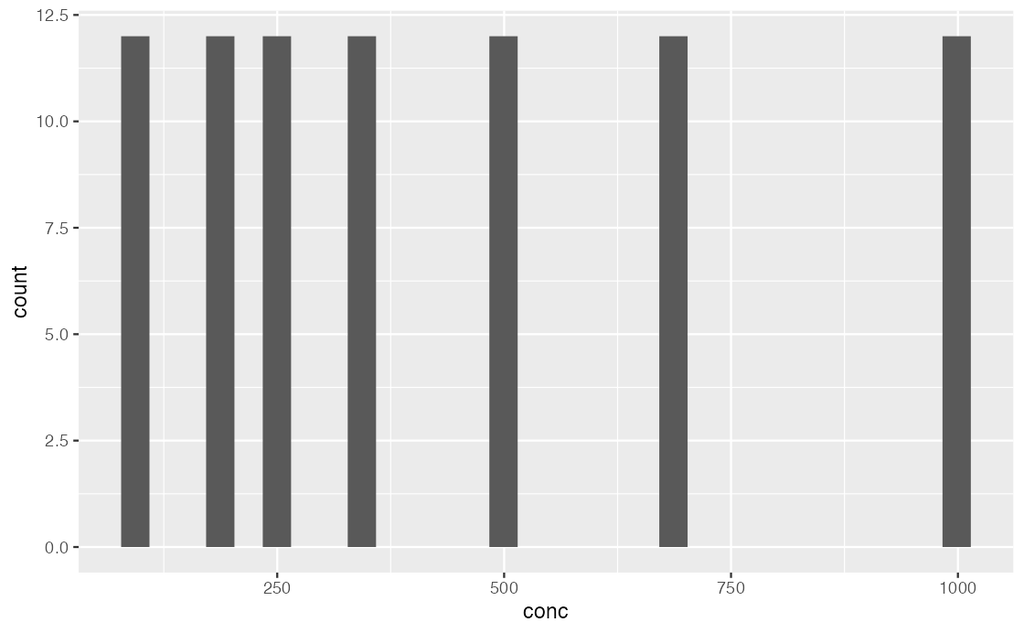

```r
df_co2 %>% ggplot(aes(x = conc)) + geom_histogram()
```

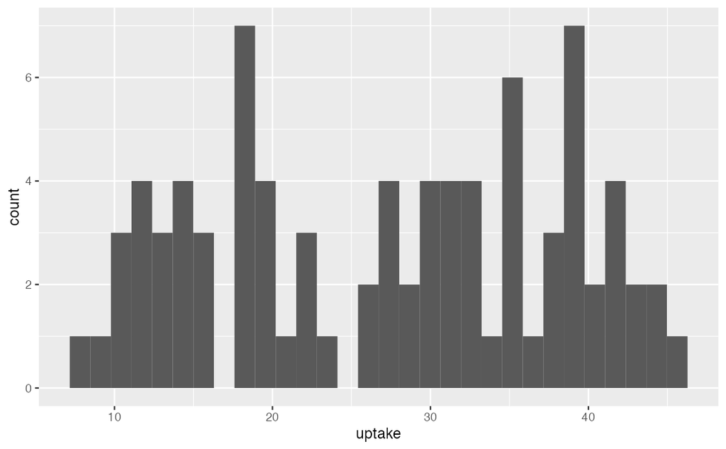

```r
df_co2 %>% ggplot(aes(x = uptake)) + geom_histogram()
```

#### 3.2.2.2 Box Plots

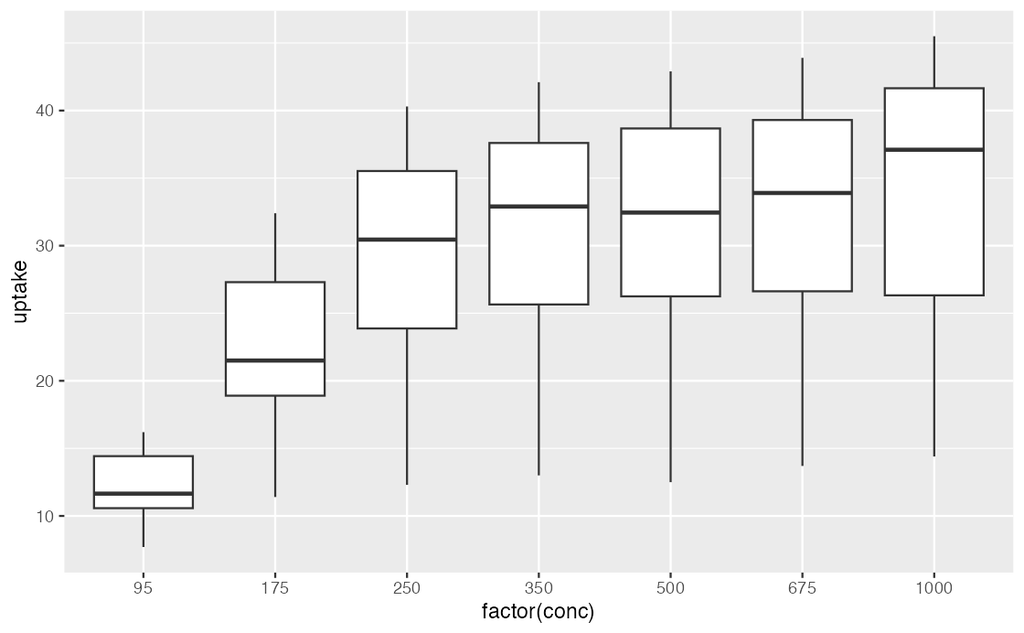

```r
df_co2 %>% ggplot(aes(x = factor(conc), y = uptake)) + geom_boxplot()
```

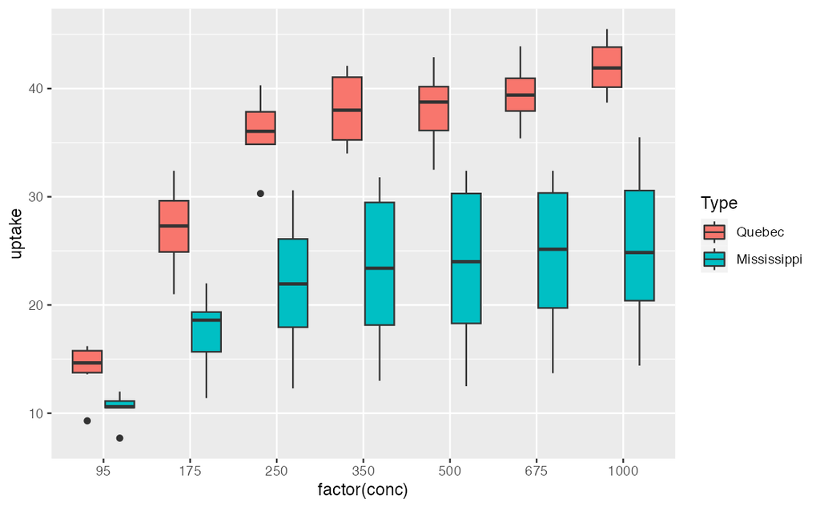

```r
df_co2 %>% ggplot(aes(x = factor(conc), y = uptake, fill = Type)) + geom_boxplot()
```

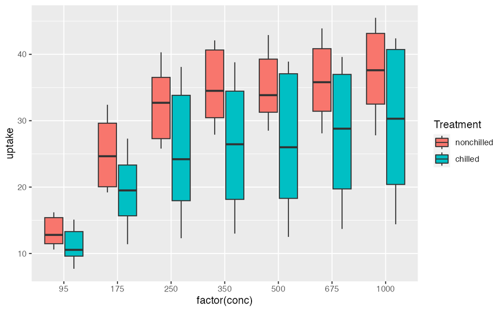

```r
df_co2 %>% ggplot(aes(x = factor(conc), y = uptake, fill = Treatment)) + geom_boxplot()
```

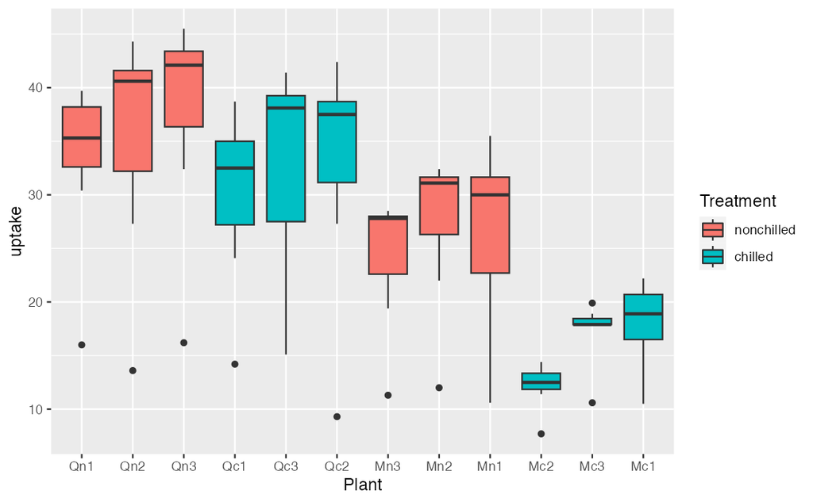

```r
df_co2 %>% ggplot(aes(x = Plant, y = uptake, fill = Treatment)) + geom_boxplot()
```

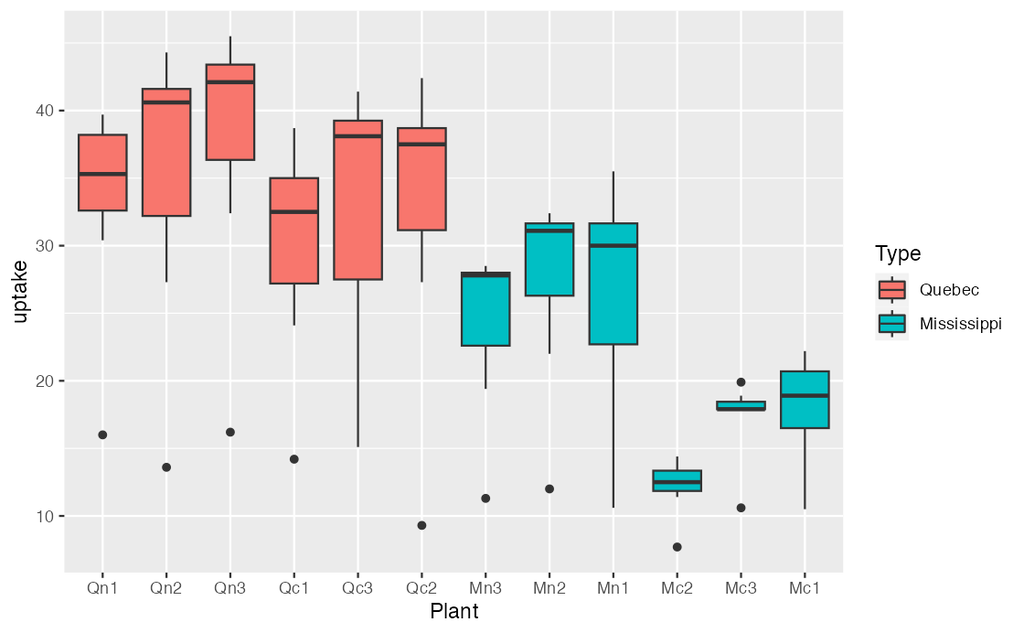

```r
df_co2 %>% ggplot(aes(x = Plant, y = uptake, fill = Type)) + geom_boxplot()
```

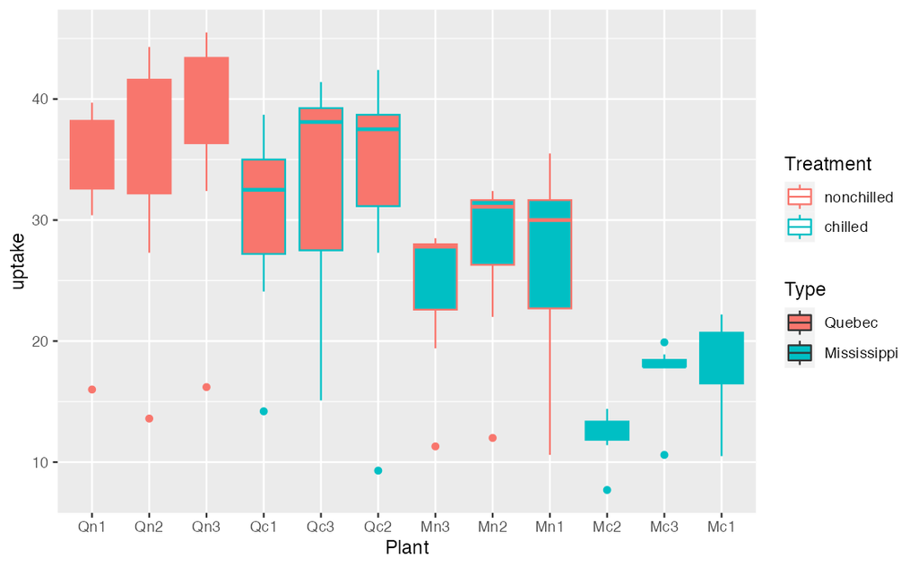

```r
df_co2 %>% ggplot(aes(x = Plant, y = uptake, fill = Type, color = Treatment)) + geom_boxplot()
```

What can you see? Write your observations.

#### 3.2.2.3 Scatter Plots

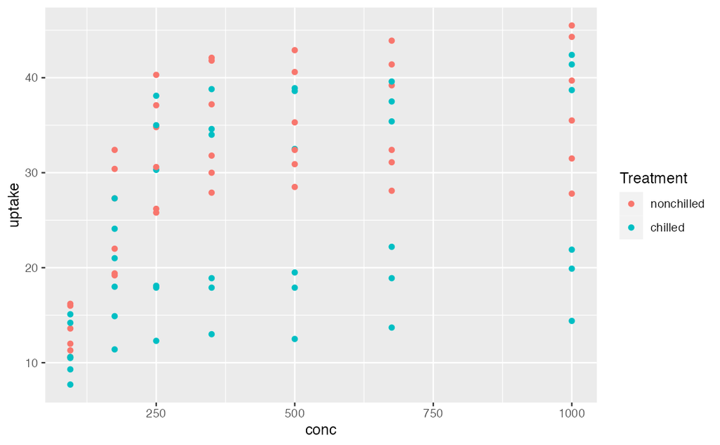

```r
df_co2 %>% ggplot(aes(x = conc, y = uptake, color = Treatment)) + geom_point()
```

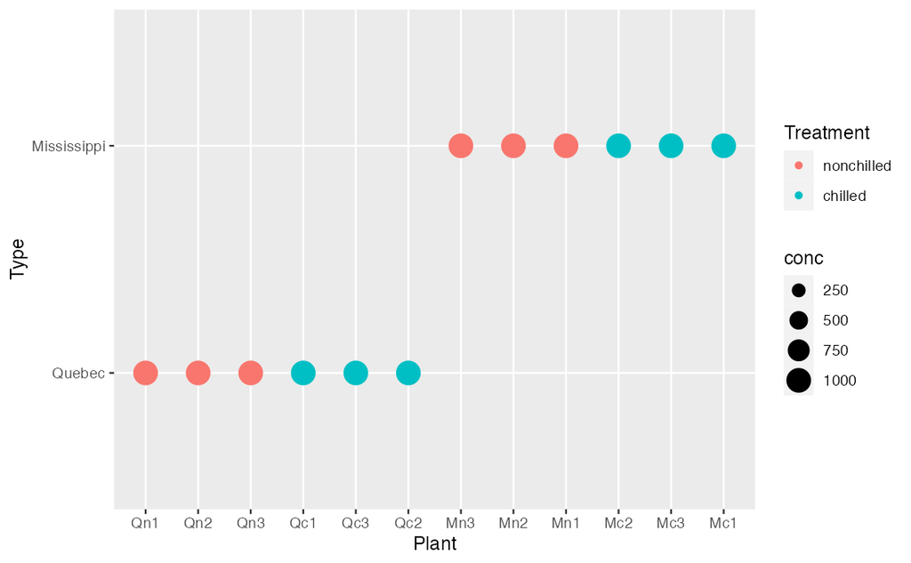

```r
df_co2 %>% ggplot(aes(x = Plant, y = Type, color = Treatment, size = conc)) + geom_point()
```

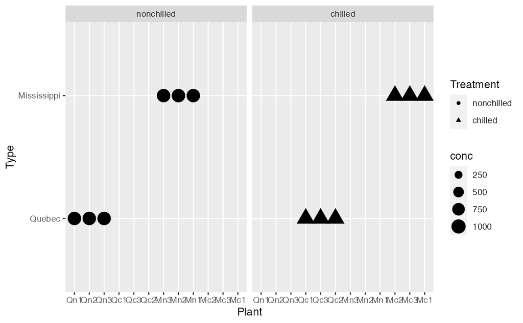

```r
df_co2 %>% ggplot(aes(x = Plant, y = Type, size = conc, shape = Treatment)) + geom_point() + facet_wrap(vars(Treatment))
```

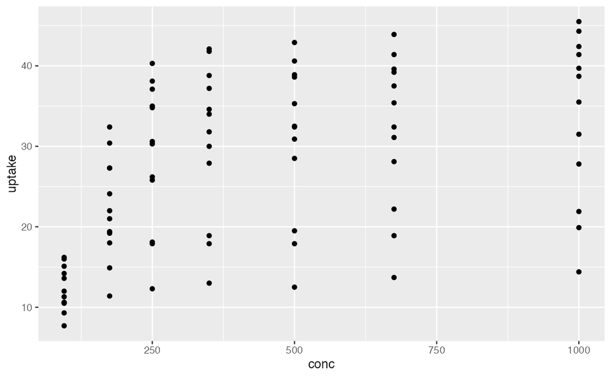

```r
ggplot(data = CO2) +
  geom_point(aes(x = conc, y = uptake))
```

The following prints a vector.

```r
df_co2 %>% distinct(conc) %>% pull()
```

```
[1]   95  175  250  350  500  675 1000
```

The following code generates a data frame.

```r
df_co2 %>% distinct(conc)
```

| conc |
| --- |
| 95 |
| 175 |
| 250 |
| 350 |
| 500 |
| 675 |
| 1000 |

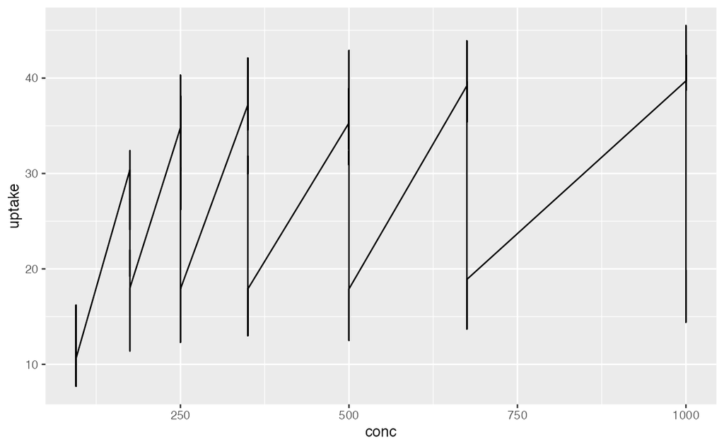

```r
ggplot(data = CO2) +
  geom_line(aes(x = conc, y = uptake))
```

### 3.2.3 Example. `datasets::Seatbelts`

Search the data information.

**Road Casualties in Great Britain 1969–84**

- Seatbelts is a multiple time series, with columns
- DriversKilled: car drivers killed.
- drivers: same as UKDriverDeaths.
- front: front-seat passengers killed or seriously injured.
- rear: rear-seat passengers killed or seriously injured.
- kms: distance driven.
- PetrolPrice: petrol price.
- VanKilled: number of van (‘light goods vehicle’) drivers.
- law: 0/1: was the law in effect that month?

**References** Harvey, A. C. and Durbin, J. (1986). The effects of seat belt legislation on British road casualties: A case study in structural time series modelling. Journal of the Royal Statistical Society series A, 149, 187–227. doi:10.2307/2981553.

*The paper is available as you log-in to ICU Library > E-Databases > JSTOR*

Can you see the difference of the following two codes?

```r
head(Seatbelts)
```

```
     DriversKilled drivers front rear   kms PetrolPrice VanKilled law
[1,]           107    1687   867  269  9059   0.1029718        12   0
[2,]            97    1508   825  265  7685   0.1023630         6   0
[3,]           102    1507   806  319  9963   0.1020625        12   0
[4,]            87    1385   814  407 10955   0.1008733         8   0
[5,]           119    1632   991  454 11823   0.1010197        10   0
[6,]           106    1511   945  427 12391   0.1005812        13   0
```

```r
df_sb <- as_tibble(datasets::Seatbelts)
df_sb
```

| DriversKilled | drivers | front | rear | kms | PetrolPrice | VanKilled | law |
| --- | --- | --- | --- | --- | --- | --- | --- |
| 107 | 1687 | 867 | 269 | 9059 | 0.10297181 | 12 | 0 |
| 97 | 1508 | 825 | 265 | 7685 | 0.10236300 | 6 | 0 |
| 102 | 1507 | 806 | 319 | 9963 | 0.10206249 | 12 | 0 |
| 87 | 1385 | 814 | 407 | 10955 | 0.10087330 | 8 | 0 |
| 119 | 1632 | 991 | 454 | 11823 | 0.10101967 | 10 | 0 |
| 106 | 1511 | 945 | 427 | 12391 | 0.10058119 | 13 | 0 |
| 110 | 1559 | 1004 | 522 | 13460 | 0.10377398 | 11 | 0 |
| 106 | 1630 | 1091 | 536 | 14055 | 0.10407640 | 6 | 0 |
| 107 | 1579 | 958 | 405 | 12106 | 0.10377398 | 10 | 0 |
| 134 | 1653 | 850 | 437 | 11372 | 0.10302640 | 16 | 0 |

[output cut: 182 more lines]

```r
summary(df_sb)
```

```
 DriversKilled      drivers         front             rear            kms
 Min.   : 60.0   Min.   :1057   Min.   : 426.0   Min.   :224.0   Min.   : 7685
 1st Qu.:104.8   1st Qu.:1462   1st Qu.: 715.5   1st Qu.:344.8   1st Qu.:12685
 Median :118.5   Median :1631   Median : 828.5   Median :401.5   Median :14987
 Mean   :122.8   Mean   :1670   Mean   : 837.2   Mean   :401.2   Mean   :14994
 3rd Qu.:138.0   3rd Qu.:1851   3rd Qu.: 950.8   3rd Qu.:456.2   3rd Qu.:17202
 Max.   :198.0   Max.   :2654   Max.   :1299.0   Max.   :646.0   Max.   :21626
  PetrolPrice        VanKilled           law
 Min.   :0.08118   Min.   : 2.000   Min.   :0.0000
 1st Qu.:0.09258   1st Qu.: 6.000   1st Qu.:0.0000
 Median :0.10448   Median : 8.000   Median :0.0000
 Mean   :0.10362   Mean   : 9.057   Mean   :0.1198
 3rd Qu.:0.11406   3rd Qu.:12.000   3rd Qu.:0.0000
 Max.   :0.13303   Max.   :17.000   Max.   :1.0000
```

Which visualization do you apply?

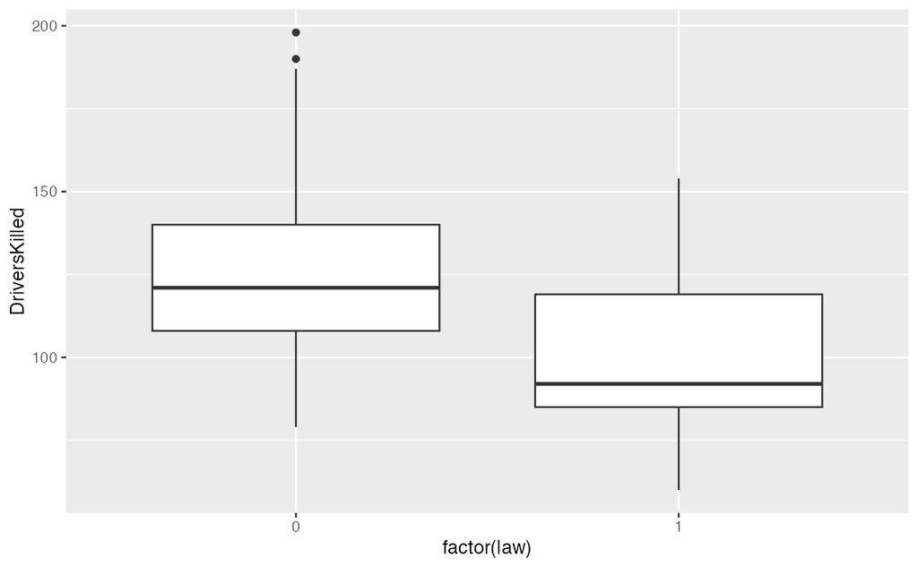

```r
df_sb %>% ggplot(aes(x = factor(law), y = DriversKilled)) + geom_boxplot()
```

What do you observe above?

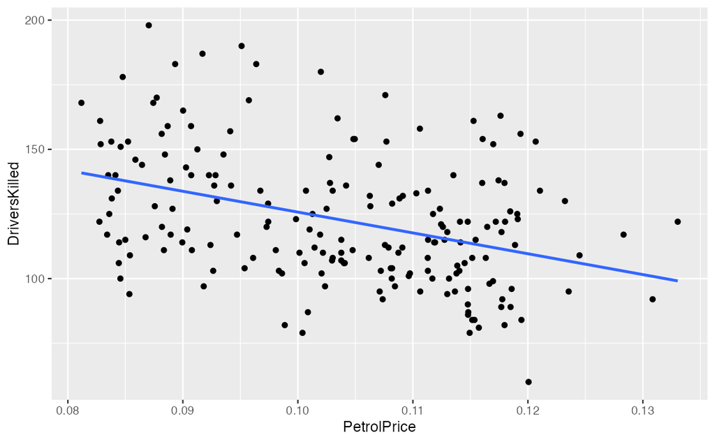

```r
df_sb %>% ggplot(aes(x = PetrolPrice, y = DriversKilled)) + geom_point() +
  geom_smooth(formula = y~x, method = "lm", se = FALSE)
```

What can you see above?

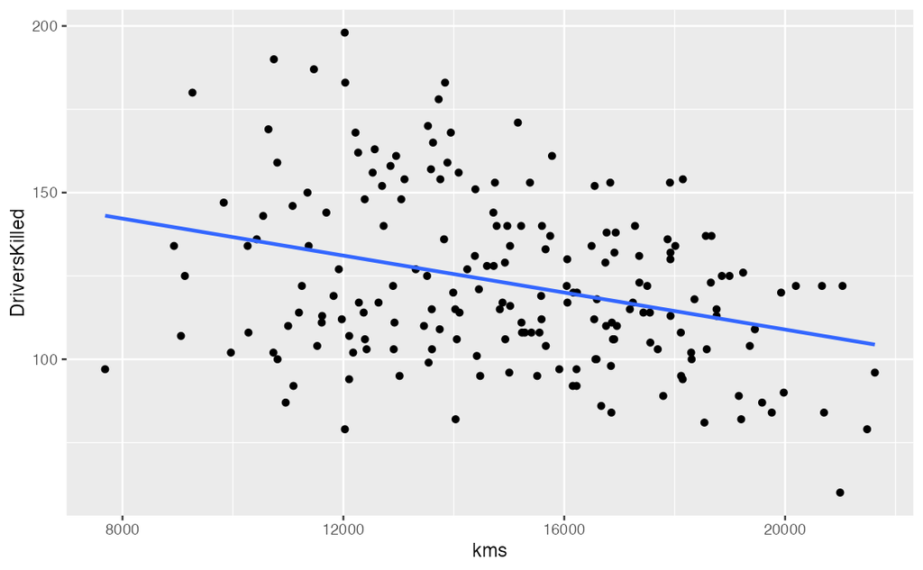

```r
df_sb %>% ggplot(aes(x = kms, y = DriversKilled)) + geom_point() +
  geom_smooth(formula = y~x, method = "lm", se = FALSE)
```

What can you see above?

We will learn how to use `pivot_longer` and `pivot_wider` in EDA4.

```r
df_sb %>%
  pivot_longer(cols = 2:4, names_to = "seat", values_to = "value")
```

| DriversKilled | kms | PetrolPrice | VanKilled | law | seat | value |
| --- | --- | --- | --- | --- | --- | --- |
| 107 | 9059 | 0.10297181 | 12 | 0 | drivers | 1687 |
| 107 | 9059 | 0.10297181 | 12 | 0 | front | 867 |
| 107 | 9059 | 0.10297181 | 12 | 0 | rear | 269 |
| 97 | 7685 | 0.10236300 | 6 | 0 | drivers | 1508 |
| 97 | 7685 | 0.10236300 | 6 | 0 | front | 825 |
| 97 | 7685 | 0.10236300 | 6 | 0 | rear | 265 |
| 102 | 9963 | 0.10206249 | 12 | 0 | drivers | 1507 |
| 102 | 9963 | 0.10206249 | 12 | 0 | front | 806 |
| 102 | 9963 | 0.10206249 | 12 | 0 | rear | 319 |
| 87 | 10955 | 0.10087330 | 8 | 0 | drivers | 1385 |

[output cut: 566 more lines]

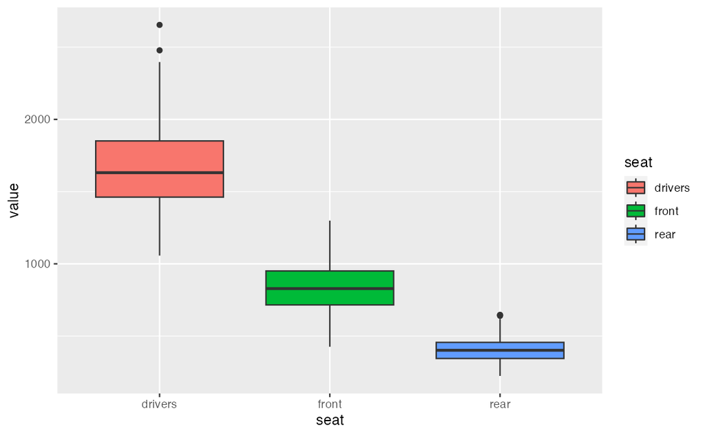

```r
df_sb %>%
  pivot_longer(cols = 2:4, names_to = "seat", values_to = "value") %>%
  ggplot() + geom_boxplot(aes(x = seat, y = value, fill = seat))
```

What can you observe?

```r
df %>% filter(continent == "Asia") %>%
  ggplot(aes(x = year, y = gdpPercap, color = country)) + geom_line()
```

[output not shown]

Appropriate graph?

## 3.3 Gapminder

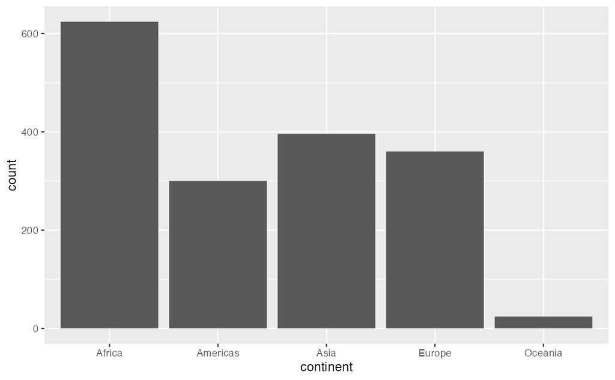

```r
ggplot(df, aes(x = continent)) + geom_bar()
```

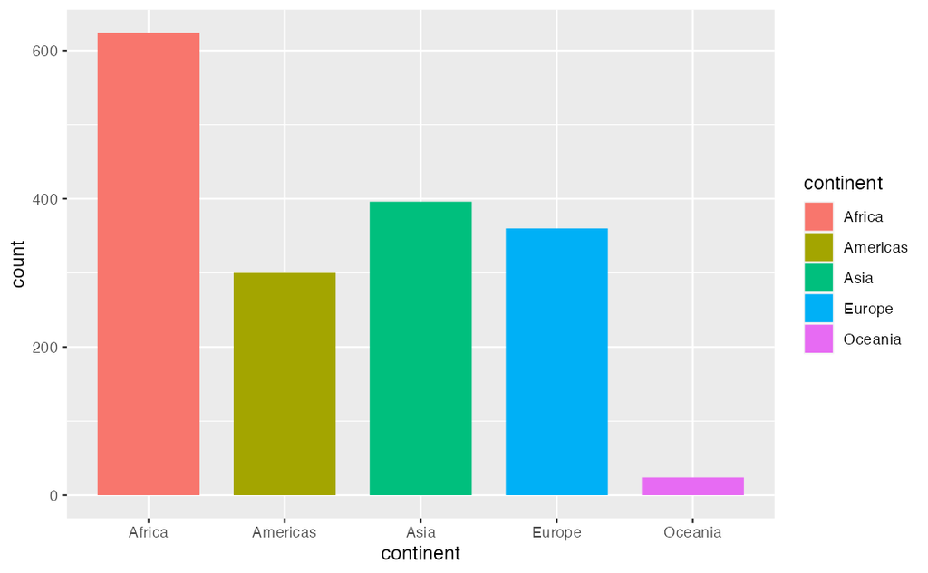

```r
ggplot(df, aes(x = continent, fill = continent)) + geom_bar(width = 0.75)
```

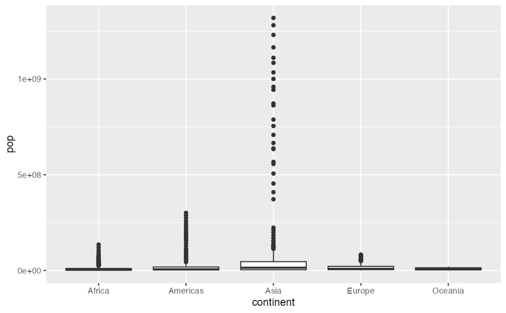

```r
ggplot(df, aes(x = continent, y = pop)) + geom_boxplot()
```

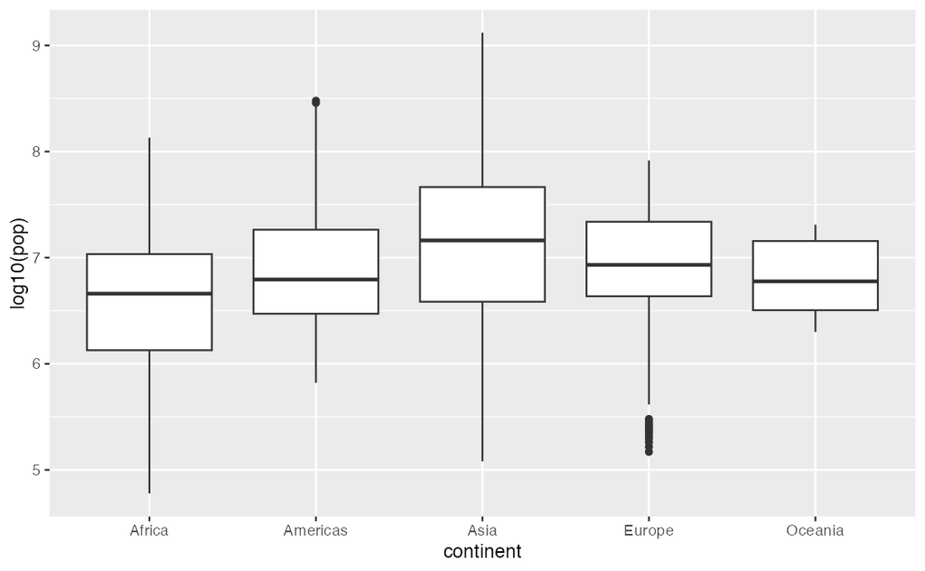

```r
ggplot(df, aes(x = continent, y = log10(pop))) + geom_boxplot()
```

Alternately, you can use `coord_trans(x = "identity", y = "log10")` in stead of `y = log10(pop)`. Can you see the difference?

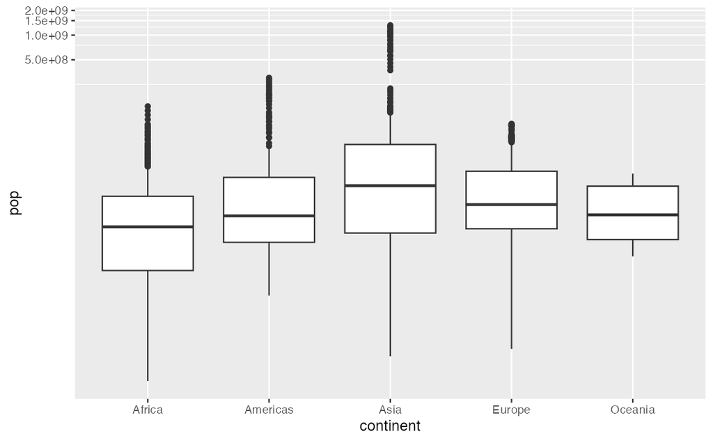

```r
ggplot(df, aes(x = continent, y = pop)) + geom_boxplot() +
  coord_trans(x = "identity", y = "log10")
```

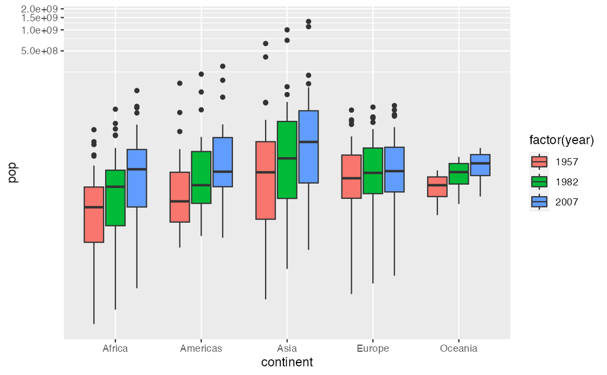

```r
df %>% filter(year %in% c(1957, 1982, 2007)) %>%
  ggplot() + geom_boxplot(aes(x = continent, y = pop, fill = factor(year))) +
    coord_trans(x = "identity", y = "log10")
```

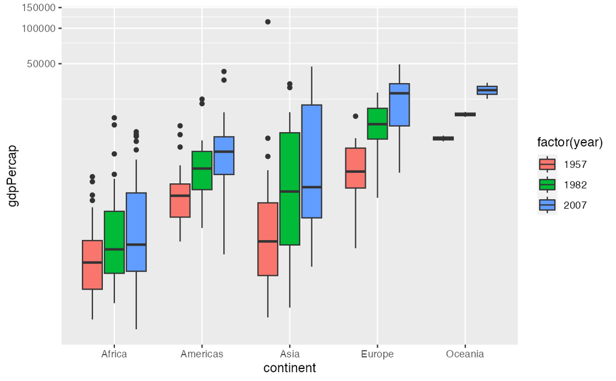

```r
df %>% filter(year %in% c(1957, 1982, 2007)) %>%
  ggplot() + geom_boxplot(aes(x = continent, y = gdpPercap, fill = factor(year))) +
  coord_trans(x = "identity", y = "log10")
```

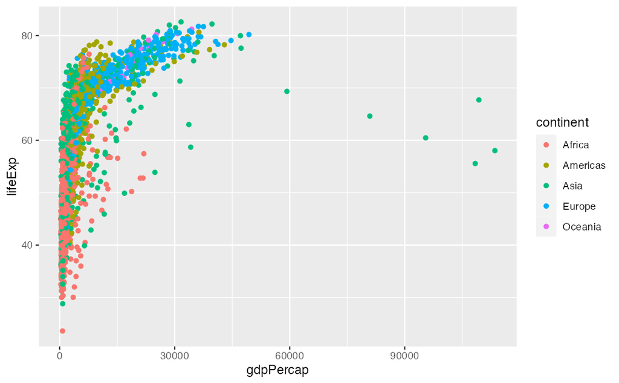

```r
ggplot(df, aes(gdpPercap, lifeExp)) + geom_point(aes(color=continent))
```

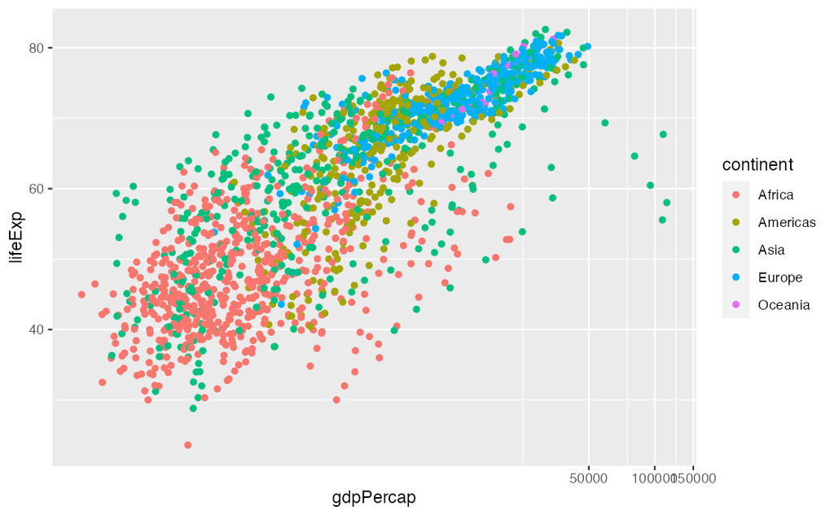

```r
df %>% ggplot(aes(gdpPercap, lifeExp, color = continent)) + geom_point() +
  coord_trans(x = "log10", y = "identity")
```

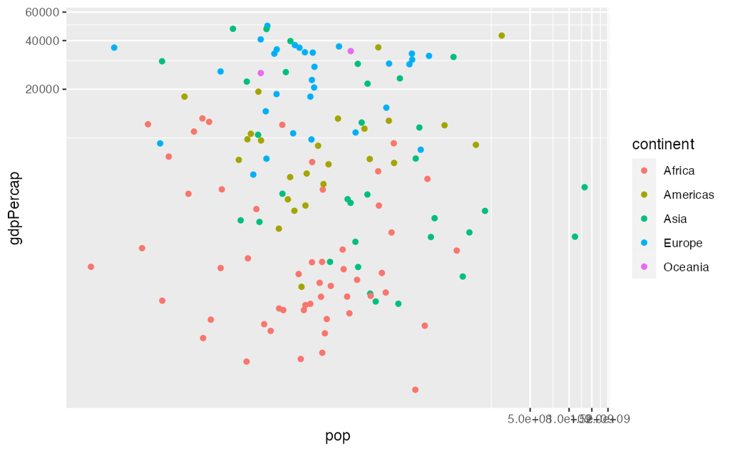

```r
df %>% filter(year %in% c(2007)) %>%
  ggplot() + geom_point(aes(x = pop, y = gdpPercap, col = continent)) +
  coord_trans(x = "log10", y = "log10")
```

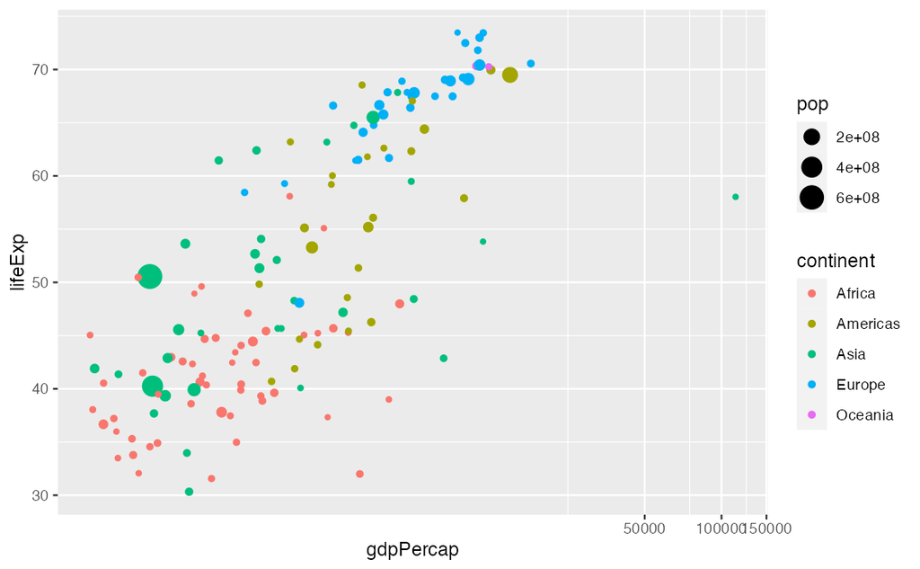

```r
df %>% filter(year %in% c(1957)) %>%
  ggplot() + geom_point(aes(x = gdpPercap, y = lifeExp, col = continent, size = pop)) +
  coord_trans(x = "log10", y = "identity")
```

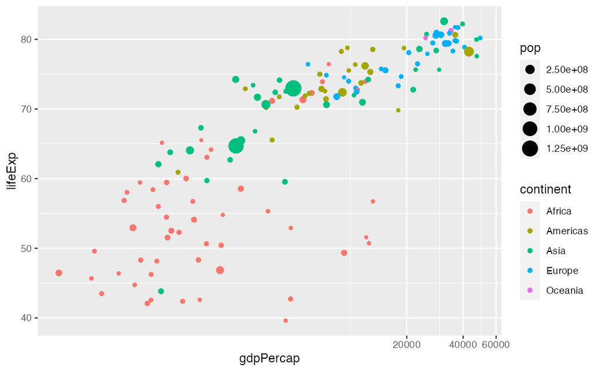

```r
df %>% filter(year %in% c(2007)) %>%
  ggplot() + geom_point(aes(x = gdpPercap, y = lifeExp, col = continent, size = pop)) +
  coord_trans(x = "log10", y = "identity")
```

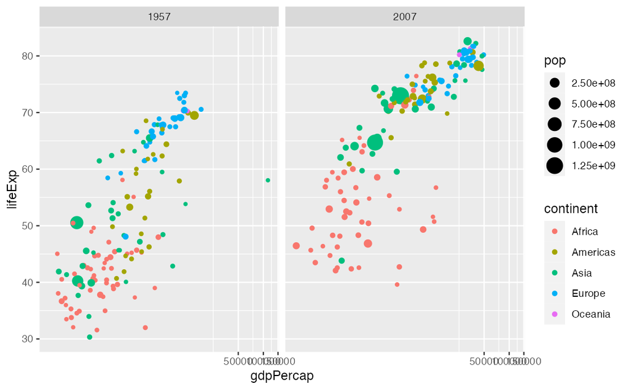

```r
df %>% filter(year %in% c(1957, 2007)) %>%
  ggplot() + geom_point(aes(x = gdpPercap, y = lifeExp, col = continent, size = pop)) +
  coord_trans(x = "log10", y = "identity") +
  facet_wrap(vars(year))
```